# Variable cleaning proposals

Russ

8/20/2021

## Intro

This is Russ’s first stab at analysis for the international student survey.

### Part 1: Exclusion criteria

The main goals of the analysis are:  
- see if there are repeated emails and Ip.address with similiar data (did people take the survey more than once for more money?)  
- examine range of each variable (Are there obviously weird results? like people under the age of 18 or over 90? Taiwanese local student who took the survey? )  
- look for missing or unusable values (Are they so missing or so off that they need to be excluded)  
- look for other exclusion criteria (Other schools aside from TMU)  
- Formalize exclusion criteria, exclude people with code, and make exclusion flow chart

### Part 2: Comparability of two cross-sectional group of survey respondents

- Compare the baseline characteristics of the January Survey group and the July survey group
- Chi square test?

### Part 3: Outcomes of interest

- health behaviors (Did they change?)  
  – Look at each behavior individually? Or develop a composite score? (lit review may help)  
  – make composite by category?  
  – Odds ratio?
- beliefs and perceptions  
  – usefulness of masks? Perception of risk for different countries?
- Impressions of the Taiwanese govt  
  – change after outbreak?  
  – Do chinese speakers have different experiences?  
  – Does information source/ media choice affect impressions?  
  -Main dependent variable: time?  
  – then stratify/control for other demographics?  
  – univariate regression for cohort group (time) multivariate regression for time + other factors?

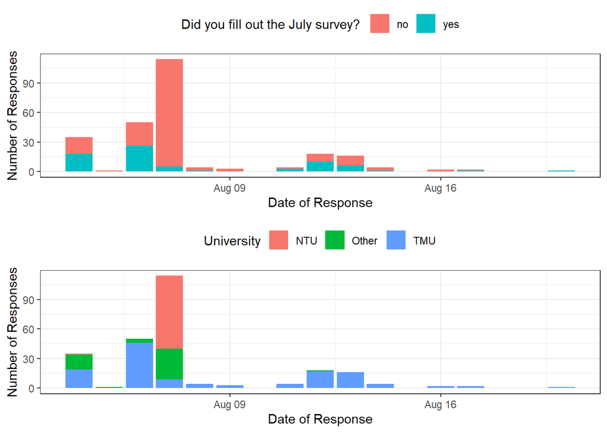

```r
require(ggplot2)
plot2 <- int_students_total[int_students_total$survey_round=="round_3",] %>%
  filter(survey_time > "2021-06-01")%>%
ggplot()+
  geom_bar(aes(x=date(survey_time),
               fill=university2))+
  theme_bw()+
  #ggtitle("Survey Responses by Day")+
  xlab("Date of Response")+
  ylab("Number of Responses")+
  guides(fill=guide_legend(title="University")) +
  theme(legend.direction='horizontal',
        legend.position = "top")

plot1 <- int_students_total[int_students_total$survey_round=="round_3",] %>%
  filter(survey_time > "2021-06-01")%>%
  ggplot()+
  geom_bar(aes(x=date(survey_time),
               fill=july_survey))+
  theme_bw()+
  #ggtitle("Survey Responses by Day")+
  xlab("Date of Response")+
  ylab("Number of Responses")+
  guides(fill=guide_legend(title="Did you fill out the July survey?"))+
  theme(legend.direction='horizontal',
        legend.position = "top")


library(ggpubr)


ggarrange(plotlist = list(plot1,plot2),nrow = 2)
```

# Draft: table 1 version 1.0

## Basic characteristics stratified by round 1 or round 3

Round 3 refers to people filling out the survey after August 4th  
Round 1 to before august 4th

- Test for continous variables = anova: analysis of variance test; the default test for continuous variables. When LHS variable has two levels, equivalent to two-sample t-test.
- test for categorical variables = chisq: chi-square goodness of fit test for equal counts of a categorical variable across categories; the default for categorical or factor variables
- test for orderd = trend: trend test for equal distribution of an ordered variable across a categorical variable; the default for ordered factor variables  
  (currently none of the variables in this data set are set as ordered factors, but it would make sense for many of them to be changed to ordered factors, especially education level, chinese language ability and all the opinion/knowledge/behavior change variables),
- NA or missing values show up as Nmiss in the table, values are presented in a count (percent) format

```r
require(knitr)
require(arsenal)

int_students_total$survey_round2 <- ifelse(int_students_total$survey_round=="round_3","round_3","round_1")

  kable(summary(tableby(survey_round2~age+
                          gender+
                          country_origin+
                          ethnicity+
                          chinese_lang+
                          native_lang+
                          religion+
                          religion_attendance+
                          education_level+
                          university2+
                          health_background+
                          months_in_taiwan+
                          opn_twgvt_enoughinfo+
                          opn_twgvt_enougregs+
                          opn_infosource_worst+
                          opn_country_lowrisk+
                          opn_country_highrisk+
                          july_survey,
                        data = int_students_total,
                        control=tableby.control(total=FALSE,
                                                cat.simplify=FALSE,
                                                numeric.test = "anova",
                                                cat.test = "chisq",
                                                ordered.test = "trend",
                                                cat.stats=c("Nmiss",
                                                            "countpct"),
                                                digits=1)),text = TRUE))
```

round_1 (N=279)

round_3 (N=254)

p value

age

< 0.001

- Mean (SD)

31.1 (5.3)

27.5 (5.7)

- Range

18.0 - 50.0

19.0 - 51.0

gender

0.342

- female

150 (53.8%)

152 (59.8%)

- male

127 (45.5%)

101 (39.8%)

- other

2 (0.7%)

1 (0.4%)

country_origin

< 0.001

- africa

1 (0.4%)

0 (0.0%)

- bangladesh

1 (0.4%)

1 (0.4%)

- belize

1 (0.4%)

1 (0.4%)

- burkina faso

3 (1.1%)

0 (0.0%)

- cameroon

1 (0.4%)

0 (0.0%)

- canada

0 (0.0%)

1 (0.4%)

- chile

2 (0.7%)

1 (0.4%)

- ecuador

1 (0.4%)

0 (0.0%)

- estonia

1 (0.4%)

0 (0.0%)

- eswatini

3 (1.1%)

1 (0.4%)

- gambia

2 (0.7%)

0 (0.0%)

- gb

0 (0.0%)

1 (0.4%)

- guatemala

5 (1.8%)

1 (0.4%)

- haiti

3 (1.1%)

0 (0.0%)

- honduras

5 (1.8%)

0 (0.0%)

- india

18 (6.5%)

11 (4.3%)

- indonesia

92 (33.0%)

36 (14.2%)

- malawi

5 (1.8%)

6 (2.4%)

- malaysia

1 (0.4%)

3 (1.2%)

- marshall islands

2 (0.7%)

2 (0.8%)

- mongolia

11 (3.9%)

3 (1.2%)

- myanmar

1 (0.4%)

1 (0.4%)

- nicaragua

2 (0.7%)

1 (0.4%)

- nigeria

2 (0.7%)

0 (0.0%)

- out

1 (0.4%)

0 (0.0%)

- paraguay

0 (0.0%)

1 (0.4%)

- philippines

2 (0.7%)

1 (0.4%)

- russia

1 (0.4%)

1 (0.4%)

- sa

2 (0.7%)

0 (0.0%)

- saint christopher and nevis

1 (0.4%)

0 (0.0%)

- saint kitts and nevis

1 (0.4%)

0 (0.0%)

- saint lucia

1 (0.4%)

1 (0.4%)

- sierra leone

1 (0.4%)

1 (0.4%)

- singapore

1 (0.4%)

1 (0.4%)

- south africa

1 (0.4%)

1 (0.4%)

- st. vincent and the grenadines

3 (1.1%)

1 (0.4%)

- suriname

0 (0.0%)

1 (0.4%)

- sweden

0 (0.0%)

1 (0.4%)

- thailand

10 (3.6%)

9 (3.5%)

- united kingdom

1 (0.4%)

3 (1.2%)

- united states

2 (0.7%)

103 (40.6%)

- usa/macau/hong kong

1 (0.4%)

0 (0.0%)

- ut

0 (0.0%)

15 (5.9%)

- vietnam

86 (30.8%)

44 (17.3%)

- vn

1 (0.4%)

0 (0.0%)

ethnicity

< 0.001

- american indian or alaska native

0 (0.0%)

1 (0.4%)

- asian or asian indian

224 (80.3%)

112 (44.1%)

- black or african american

23 (8.2%)

39 (15.4%)

- hispanic, latino or spanish

13 (4.7%)

4 (1.6%)

- other

15 (5.4%)

5 (2.0%)

- white

4 (1.4%)

93 (36.6%)

chinese_lang

< 0.001

- advanced

1 (0.4%)

19 (7.5%)

- basic

97 (34.8%)

130 (51.2%)

- intermediate

18 (6.5%)

32 (12.6%)

- none

163 (58.4%)

73 (28.7%)

native_lang

< 0.001

- dutch

0 (0.0%)

1 (0.4%)

- english

20 (7.2%)

127 (50.0%)

- english indonesian

15 (5.4%)

3 (1.2%)

- english other

6 (2.2%)

5 (2.0%)

- english spanish

7 (2.5%)

2 (0.8%)

- english thai

0 (0.0%)

1 (0.4%)

- english vietnamese

8 (2.9%)

2 (0.8%)

- french

2 (0.7%)

0 (0.0%)

- french other

2 (0.7%)

0 (0.0%)

- indonesian

75 (26.9%)

31 (12.2%)

- indonesian other

0 (0.0%)

1 (0.4%)

- mandarin chinese

0 (0.0%)

3 (1.2%)

- mandarin chinese english

1 (0.4%)

3 (1.2%)

- mandarin chinese english indonesian

1 (0.4%)

0 (0.0%)

- mandarin chinese english other

1 (0.4%)

0 (0.0%)

- mandarin chinese indonesian

0 (0.0%)

1 (0.4%)

- other

42 (15.1%)

21 (8.3%)

- spanish

9 (3.2%)

3 (1.2%)

- tagalog

2 (0.7%)

1 (0.4%)

- thai

10 (3.6%)

8 (3.1%)

- vietnamese

78 (28.0%)

41 (16.1%)

religion

< 0.001

- buddhism

40 (14.3%)

27 (10.6%)

- christianity

57 (20.4%)

67 (26.4%)

- folk religion

1 (0.4%)

0 (0.0%)

- hinduism

19 (6.8%)

13 (5.1%)

- islam

78 (28.0%)

26 (10.2%)

- judaism

0 (0.0%)

1 (0.4%)

- no religion

79 (28.3%)

115 (45.3%)

- other

5 (1.8%)

5 (2.0%)

religion_attendance

< 0.001

- always

58 (20.8%)

14 (5.5%)

- never

64 (22.9%)

88 (34.6%)

- often

37 (13.3%)

29 (11.4%)

- seldom

65 (23.3%)

65 (25.6%)

- sometimes

55 (19.7%)

58 (22.8%)

education_level

< 0.001

- associate degree

0 (0.0%)

8 (3.1%)

- bachelor� degree (e.g. ba, bs)

67 (24.0%)

113 (44.5%)

- doctorate (e.g. phd, edd)

13 (4.7%)

10 (3.9%)

- high school degree

1 (0.4%)

18 (7.1%)

- master� degree (e.g. ma, ms, med)

165 (59.1%)

85 (33.5%)

- professional degree (e.g. md, dds, dvm)

33 (11.8%)

20 (7.9%)

university2

< 0.001

- NTU

1 (0.4%)

75 (29.5%)

- Other

4 (1.4%)

52 (20.5%)

- TMU

274 (98.2%)

127 (50.0%)

health_background

< 0.001

- no

80 (28.7%)

143 (56.3%)

- yes

199 (71.3%)

111 (43.7%)

months_in_taiwan

0.434

- Mean (SD)

21.1 (16.8)

22.2 (15.5)

- Range

0.0 - 82.0

3.0 - 100.0

opn_twgvt_enoughinfo

< 0.001

- agree

140 (50.2%)

114 (44.9%)

- disagree

6 (2.2%)

10 (3.9%)

- neutral

21 (7.5%)

58 (22.8%)

- strongly agree

111 (39.8%)

72 (28.3%)

- strongly disagree

1 (0.4%)

0 (0.0%)

opn_twgvt_enougregs

< 0.001

- strongly disagree

1 (0.4%)

0 (0.0%)

- disagree

1 (0.4%)

3 (1.2%)

- neutral

13 (4.7%)

58 (22.8%)

- agree

140 (50.2%)

113 (44.5%)

- strongly agree

124 (44.4%)

80 (31.5%)

opn_infosource_worst

< 0.001

- friends/classmates/schoolmates

160 (57.3%)

162 (63.8%)

- information released by your university

1 (0.4%)

13 (5.1%)

- other

73 (26.2%)

28 (11.0%)

- research results and journal from the world

13 (4.7%)

12 (4.7%)

- taiwan government

8 (2.9%)

30 (11.8%)

- the world health organization (who)

24 (8.6%)

9 (3.5%)

opn_country_lowrisk

< 0.001

- china

3 (1.1%)

74 (29.1%)

- italy

0 (0.0%)

4 (1.6%)

- other

31 (11.1%)

13 (5.1%)

- russia

3 (1.1%)

6 (2.4%)

- taiwan

232 (83.2%)

97 (38.2%)

- u.s.a.

10 (3.6%)

60 (23.6%)

opn_country_highrisk

< 0.001

- china

5 (1.8%)

70 (27.6%)

- italy

2 (0.7%)

4 (1.6%)

- other

30 (10.8%)

16 (6.3%)

- russia

2 (0.7%)

5 (2.0%)

- taiwan

219 (78.5%)

97 (38.2%)

- u.s.a.

21 (7.5%)

62 (24.4%)

july_survey

- N-Miss

279

0

- no

0

182 (71.7%)

- yes

0

72 (28.3%)

# Draft: table 1 version 1.1

## Basic characteristics stratified by University for responses after august 4th

```r
label(int_students_total$gender) <- "sex"
label(int_students_total$university2) <- "University"
label(int_students_total$country_origin) <- "Country of origin"
label(int_students_total$ethnicity) <- "Self-identified Race or ethnicity"
label(int_students_total$chinese_lang) <- "Self-reported Chinese language level"
label(int_students_total$religion_attendance) <- "Self-reported frequency of attending religious services"
label(int_students_total$education_level) <- "Highest education level achieved"
label(int_students_total$survey_round2) <- "Survey cohort"
label(int_students_total$health_background) <- "Self-reported health background"
label(int_students_total$months_in_taiwan) <- "Self-reported number of months living in Taiwan"
label(int_students_total$opn_twgvt_enougregs) <-"Compliance with the Taiwan governmental regulations is effective to prevent the spread of SARS CoV 2  Virus causing COVID 19"
label(int_students_total$opn_twgvt_enoughinfo) <-"The government of Taiwan provided sufficient information of COVID 19 for me"



  kable(summary(tableby(university2~age+
                          gender+
                          country_origin+
                          ethnicity+
                          chinese_lang+
                          native_lang+
                          religion+
                          religion_attendance+
                          education_level+
                          survey_round2+
                          health_background+
                          months_in_taiwan+
                          opn_twgvt_enoughinfo+
                          opn_twgvt_enougregs+
                          opn_infosource_worst+
                          opn_country_lowrisk+
                          opn_country_highrisk+
                          july_survey,
                        data = int_students_total[int_students_total$survey_round2=="round_3",],
                        control=tableby.control(total=FALSE,
                                                cat.simplify=FALSE,
                                                numeric.test = "anova",
                                                cat.test = "chisq",
                                                ordered.test = "trend",
                                                cat.stats=c("Nmiss",
                                                            "countpct"),
                                                digits=1)),text = TRUE))
```

NTU (N=75)

Other (N=52)

TMU (N=127)

p value

age

< 0.001

- Mean (SD)

24.1 (3.0)

23.9 (3.8)

30.9 (5.4)

- Range

19.0 - 32.0

19.0 - 32.0

21.0 - 51.0

sex

0.430

- female

51 (68.0%)

30 (57.7%)

71 (55.9%)

- male

24 (32.0%)

22 (42.3%)

55 (43.3%)

- other

0 (0.0%)

0 (0.0%)

1 (0.8%)

Country of origin

< 0.001

- bangladesh

0 (0.0%)

0 (0.0%)

1 (0.8%)

- belize

0 (0.0%)

1 (1.9%)

0 (0.0%)

- canada

0 (0.0%)

1 (1.9%)

0 (0.0%)

- chile

0 (0.0%)

0 (0.0%)

1 (0.8%)

- eswatini

0 (0.0%)

0 (0.0%)

1 (0.8%)

- gb

0 (0.0%)

0 (0.0%)

1 (0.8%)

- guatemala

0 (0.0%)

0 (0.0%)

1 (0.8%)

- india

0 (0.0%)

1 (1.9%)

10 (7.9%)

- indonesia

0 (0.0%)

0 (0.0%)

36 (28.3%)

- malawi

0 (0.0%)

0 (0.0%)

6 (4.7%)

- malaysia

0 (0.0%)

0 (0.0%)

3 (2.4%)

- marshall islands

0 (0.0%)

0 (0.0%)

2 (1.6%)

- mongolia

0 (0.0%)

0 (0.0%)

3 (2.4%)

- myanmar

0 (0.0%)

0 (0.0%)

1 (0.8%)

- nicaragua

0 (0.0%)

0 (0.0%)

1 (0.8%)

- paraguay

0 (0.0%)

0 (0.0%)

1 (0.8%)

- philippines

0 (0.0%)

0 (0.0%)

1 (0.8%)

- russia

0 (0.0%)

0 (0.0%)

1 (0.8%)

- saint lucia

0 (0.0%)

0 (0.0%)

1 (0.8%)

- sierra leone

0 (0.0%)

0 (0.0%)

1 (0.8%)

- singapore

1 (1.3%)

0 (0.0%)

0 (0.0%)

- south africa

0 (0.0%)

0 (0.0%)

1 (0.8%)

- st. vincent and the grenadines

0 (0.0%)

0 (0.0%)

1 (0.8%)

- suriname

0 (0.0%)

1 (1.9%)

0 (0.0%)

- sweden

0 (0.0%)

1 (1.9%)

0 (0.0%)

- thailand

0 (0.0%)

1 (1.9%)

8 (6.3%)

- united kingdom

0 (0.0%)

2 (3.8%)

1 (0.8%)

- united states

69 (92.0%)

33 (63.5%)

1 (0.8%)

- ut

5 (6.7%)

10 (19.2%)

0 (0.0%)

- vietnam

0 (0.0%)

1 (1.9%)

43 (33.9%)

Self-identified Race or ethnicity

< 0.001

- american indian or alaska native

1 (1.3%)

0 (0.0%)

0 (0.0%)

- asian or asian indian

1 (1.3%)

4 (7.7%)

107 (84.3%)

- black or african american

17 (22.7%)

13 (25.0%)

9 (7.1%)

- hispanic, latino or spanish

0 (0.0%)

1 (1.9%)

3 (2.4%)

- other

0 (0.0%)

0 (0.0%)

5 (3.9%)

- white

56 (74.7%)

34 (65.4%)

3 (2.4%)

Self-reported Chinese language level

< 0.001

- advanced

10 (13.3%)

5 (9.6%)

4 (3.1%)

- basic

44 (58.7%)

24 (46.2%)

62 (48.8%)

- intermediate

12 (16.0%)

13 (25.0%)

7 (5.5%)

- none

9 (12.0%)

10 (19.2%)

54 (42.5%)

native_lang

< 0.001

- dutch

0 (0.0%)

1 (1.9%)

0 (0.0%)

- english

74 (98.7%)

45 (86.5%)

8 (6.3%)

- english indonesian

0 (0.0%)

0 (0.0%)

3 (2.4%)

- english other

0 (0.0%)

1 (1.9%)

4 (3.1%)

- english spanish

0 (0.0%)

1 (1.9%)

1 (0.8%)

- english thai

0 (0.0%)

0 (0.0%)

1 (0.8%)

- english vietnamese

0 (0.0%)

0 (0.0%)

2 (1.6%)

- indonesian

0 (0.0%)

1 (1.9%)

30 (23.6%)

- indonesian other

0 (0.0%)

0 (0.0%)

1 (0.8%)

- mandarin chinese

0 (0.0%)

1 (1.9%)

2 (1.6%)

- mandarin chinese english

1 (1.3%)

0 (0.0%)

2 (1.6%)

- mandarin chinese indonesian

0 (0.0%)

0 (0.0%)

1 (0.8%)

- other

0 (0.0%)

0 (0.0%)

21 (16.5%)

- spanish

0 (0.0%)

0 (0.0%)

3 (2.4%)

- tagalog

0 (0.0%)

0 (0.0%)

1 (0.8%)

- thai

0 (0.0%)

1 (1.9%)

7 (5.5%)

- vietnamese

0 (0.0%)

1 (1.9%)

40 (31.5%)

religion

< 0.001

- buddhism

0 (0.0%)

3 (5.8%)

24 (18.9%)

- christianity

17 (22.7%)

26 (50.0%)

24 (18.9%)

- hinduism

0 (0.0%)

4 (7.7%)

9 (7.1%)

- islam

0 (0.0%)

1 (1.9%)

25 (19.7%)

- judaism

0 (0.0%)

1 (1.9%)

0 (0.0%)

- no religion

57 (76.0%)

17 (32.7%)

41 (32.3%)

- other

1 (1.3%)

0 (0.0%)

4 (3.1%)

Self-reported frequency of attending religious services

< 0.001

- always

0 (0.0%)

2 (3.8%)

12 (9.4%)

- never

51 (68.0%)

6 (11.5%)

31 (24.4%)

- often

2 (2.7%)

7 (13.5%)

20 (15.7%)

- seldom

13 (17.3%)

15 (28.8%)

37 (29.1%)

- sometimes

9 (12.0%)

22 (42.3%)

27 (21.3%)

Highest education level achieved

< 0.001

- associate degree

4 (5.3%)

4 (7.7%)

0 (0.0%)

- bachelor� degree (e.g. ba, bs)

48 (64.0%)

29 (55.8%)

36 (28.3%)

- doctorate (e.g. phd, edd)

0 (0.0%)

0 (0.0%)

10 (7.9%)

- high school degree

7 (9.3%)

10 (19.2%)

1 (0.8%)

- master� degree (e.g. ma, ms, med)

15 (20.0%)

6 (11.5%)

64 (50.4%)

- professional degree (e.g. md, dds, dvm)

1 (1.3%)

3 (5.8%)

16 (12.6%)

Survey cohort

< 0.001

- round_3

75 (100.0%)

52 (100.0%)

127 (100.0%)

Self-reported health background

< 0.001

- no

70 (93.3%)

29 (55.8%)

44 (34.6%)

- yes

5 (6.7%)

23 (44.2%)

83 (65.4%)

Self-reported number of months living in Taiwan

0.022

- Mean (SD)

19.7 (8.0)

19.4 (13.1)

24.9 (19.0)

- Range

4.0 - 41.0

4.0 - 81.0

3.0 - 100.0

The government of Taiwan provided sufficient information of COVID 19 for me

< 0.001

- agree

30 (40.0%)

23 (44.2%)

61 (48.0%)

- disagree

8 (10.7%)

0 (0.0%)

2 (1.6%)

- neutral

19 (25.3%)

24 (46.2%)

15 (11.8%)

- strongly agree

18 (24.0%)

5 (9.6%)

49 (38.6%)

Compliance with the Taiwan governmental regulations is effective to prevent the spread of SARS CoV 2 Virus causing COVID 19

- strongly disagree

0 (0.0%)

0 (0.0%)

0 (0.0%)

- disagree

1 (1.3%)

1 (1.9%)

1 (0.8%)

- neutral

24 (32.0%)

23 (44.2%)

11 (8.7%)

- agree

30 (40.0%)

23 (44.2%)

60 (47.2%)

- strongly agree

20 (26.7%)

5 (9.6%)

55 (43.3%)

opn_infosource_worst

< 0.001

- friends/classmates/schoolmates

62 (82.7%)

16 (30.8%)

84 (66.1%)

- information released by your university

3 (4.0%)

8 (15.4%)

2 (1.6%)

- other

0 (0.0%)

2 (3.8%)

26 (20.5%)

- research results and journal from the world

4 (5.3%)

3 (5.8%)

5 (3.9%)

- taiwan government

6 (8.0%)

20 (38.5%)

4 (3.1%)

- the world health organization (who)

0 (0.0%)

3 (5.8%)

6 (4.7%)

opn_country_lowrisk

< 0.001

- china

46 (61.3%)

23 (44.2%)

5 (3.9%)

- italy

0 (0.0%)

0 (0.0%)

4 (3.1%)

- other

0 (0.0%)

1 (1.9%)

12 (9.4%)

- russia

0 (0.0%)

2 (3.8%)

4 (3.1%)

- taiwan

0 (0.0%)

2 (3.8%)

95 (74.8%)

- u.s.a.

29 (38.7%)

24 (46.2%)

7 (5.5%)

opn_country_highrisk

< 0.001

- china

46 (61.3%)

22 (42.3%)

2 (1.6%)

- italy

0 (0.0%)

1 (1.9%)

3 (2.4%)

- other

0 (0.0%)

1 (1.9%)

15 (11.8%)

- russia

0 (0.0%)

2 (3.8%)

3 (2.4%)

- taiwan

0 (0.0%)

2 (3.8%)

95 (74.8%)

- u.s.a.

29 (38.7%)

24 (46.2%)

9 (7.1%)

july_survey

< 0.001

- no

74 (98.7%)

40 (76.9%)

68 (53.5%)

- yes

1 (1.3%)

12 (23.1%)

59 (46.5%)